# Time Series: A First Course with Bootstrap Starter

# Lesson 7-2: Discrete Fourier Transform

We introduce the data analysis tool of Discrete Fourier Transform.

## Definition 7.2.3.

Given a sample $X_1, \ldots, X_n$, the **Discrete Fourier Transform** (DFT) at the Fourier frequency $\lambda_l = 2 \pi l/n$ (for $[n/2]-n+1 \leq l \leq [n/2]$) is
$$\widetilde{X} (\lambda_l) = n^{-1/2} \sum_{t=1}^n X_t e^{-i \lambda_l
t}.$$

## Definition 7.2.4.

- The **periodogram** $I(\lambda)$ is a non-negative function of $\lambda \in [-\pi,\pi]$, constructed from the sample $X_1, \ldots, X_n$:
  $$I(\lambda) = n^{-1} { \left| \sum_{t=1}^n (X_t - \overline{X}) e^{-i
  \lambda t} \right| }^2.$$
- So $I(0) = 0$. Sometimes we consider an “uncentered” periodogram, where there is no centering by the sample mean. We denote this by $\widetilde{I} (\lambda)$, and
  $$\widetilde{I} (\lambda_l) = {| \widetilde{X} (\lambda_l) |}^2.$$
- The periodogram is an empirical version of the spectral density, and shares certain properties. Higher values correspond to cyclical effects in the data.

## Proposition 7.2.7.

- Let the vector of DFTs be denoted $\widetilde{\underline{X}}$, which has components $\widetilde{X} (\lambda_l)$.
- This is a linear function of the sample vector $\underline{X}$:
  $$\widetilde{\underline{X}} = Q^* \, \underline{X},$$
  where $Q$ was defined in Definition 6.4.3.
- Since $Q$ is unitary, $Q^{-1} = Q^*$, so we can recover the data from the DFT vector via
  $$\underline{X} = Q \, \widetilde{\underline{X}}.$$

## Exercise 7.14. DFT of an AR(1).

- We simulate an AR(1).

```r
arp.sim <- function(n,burn,ar.coefs,innovar)
{
    p <- length(ar.coefs)
    z <- rnorm(n+burn+p,sd=sqrt(innovar))
    x <- z[1:p]
    for(t in (p+1):(p+n+burn))
    {
        next.x <- sum(ar.coefs*x[(t-1):(t-p)]) + z[t]
        x <- c(x,next.x)
    }
    x <- x[(p+burn+1):(p+burn+n)]
    return(x)
}

phi <- .8
innovar <- 1
n <- 200
x.sim <- arp.sim(n,500,phi,innovar)
```

- We compute the DFT. We begin with code to compute $Q$.

```r
get.qmat <- function(mesh)
{
    mesh2 <- floor(mesh/2)
    inds <- seq(mesh2-mesh+1,mesh2)
    Q.mat <- exp(1i*2*pi*mesh^{-1}*t(t(seq(1,mesh)) %x% inds))*mesh^{-1/2}
    return(Q.mat)
}
Q.mat <- get.qmat(n)
```

- Then we use Proposition 7.2.7 to get the DFT vector. We plot the real part, imaginary part, and the modulus.

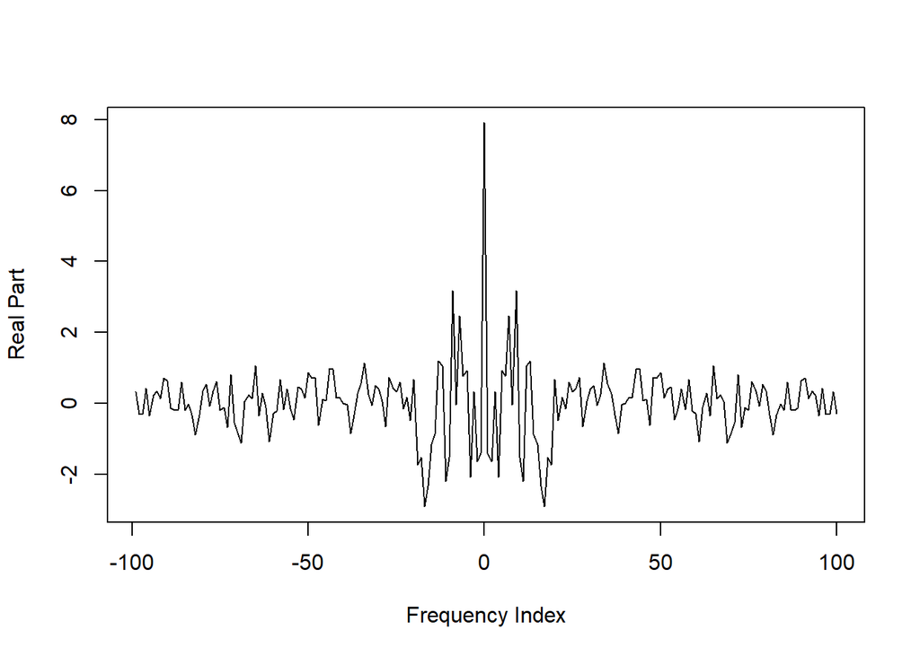

```r
x.dft <- Conj(t(Q.mat)) %*% x.sim
plot(ts(Re(x.dft),start=-floor(n/2)+1,frequency=1),
    xlab="Frequency Index",ylab="Real Part")
```

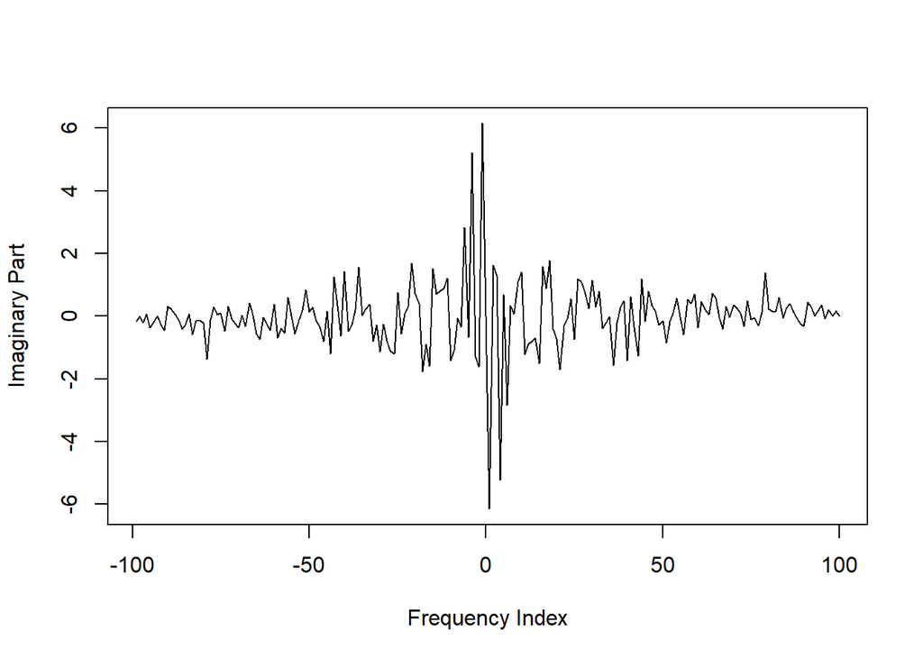

```r
plot(ts(Im(x.dft),start=-floor(n/2)+1,frequency=1),
    xlab="Frequency Index",ylab="Imaginary Part")
```

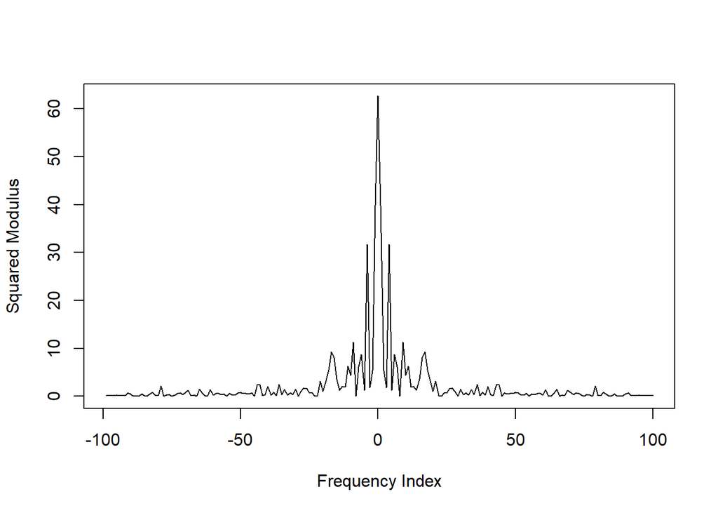

```r
plot(ts(Mod(x.dft)^2,start=-floor(n/2)+1,frequency=1),
    xlab="Frequency Index",ylab="Squared Modulus")
```

## Corollary 7.2.9. Decorrelation Property of the DFT.

- Let $X_1, \ldots, X_n$ be a sample from a mean zero, covariance stationary time series with absolutely summable ACVF and spectral density $f$. Then $\widetilde{\underline{X}}$ has approximate covariance matrix $\mbox{diag} \{ f(\lambda_{[n/2]-n+k}) \}$.
- This follows from Theorem 6.4.5:
  $$\mbox{Cov} [ \widetilde{\underline{X}} ] = Q^* \,
  \mbox{Cov} [ \underline{X} ] \, Q \approx \Lambda.$$

## Exercise 7.18. DFT of Wolfer Sunspots.

- We compute the DFT of the Wolfer sunspot data, and plot.

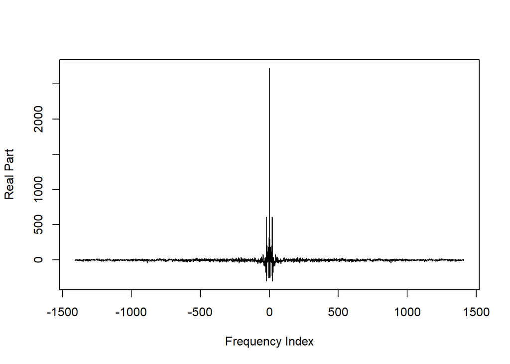

```r
wolfer <- read.table("wolfer.dat")
wolfer <- ts(wolfer,start=1749,frequency=12)
n <- length(wolfer)
Q.mat <- get.qmat(n)
x.dft <- Conj(t(Q.mat)) %*% wolfer
plot(ts(Re(x.dft),start=-floor(n/2)+1,frequency=1),
    xlab="Frequency Index",ylab="Real Part")
```

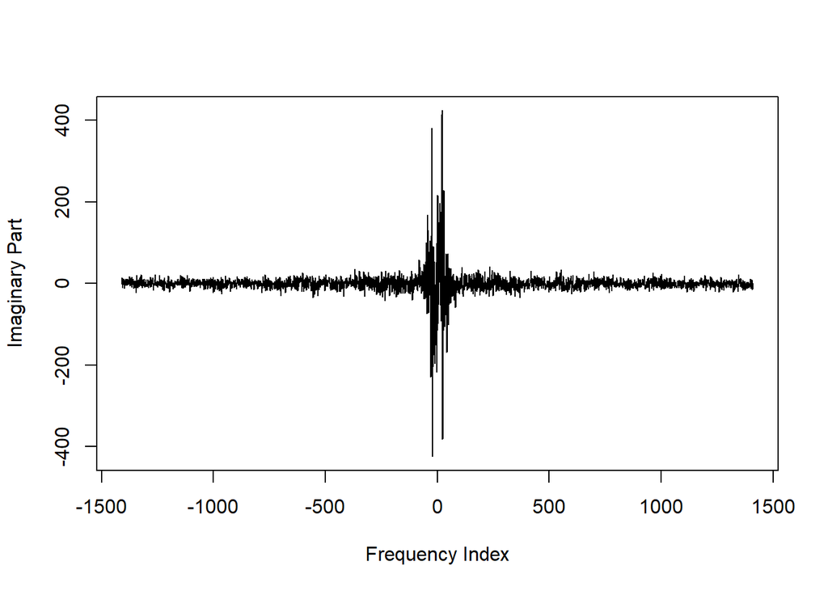

```r
plot(ts(Im(x.dft),start=-floor(n/2)+1,frequency=1),
    xlab="Frequency Index",ylab="Imaginary Part")
```

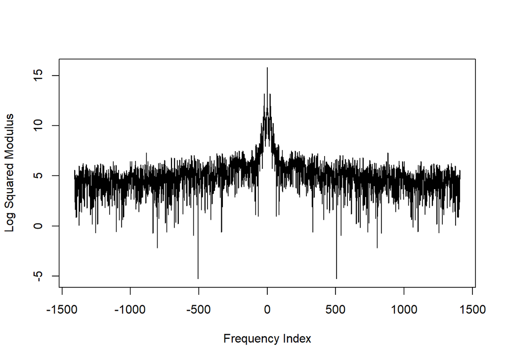

```r
plot(ts(log(Mod(x.dft)^2),start=-floor(n/2)+1,frequency=1),
    xlab="Frequency Index",ylab="Log Squared Modulus")
```

- We see higher values of the squared modulus (the uncentered periodogram) near frequency zero.

## Exercise 7.20. DFT of Mauna Loa Growth Rate.

- We compute the DFT of the Mauna Loa growth rate, and plot.

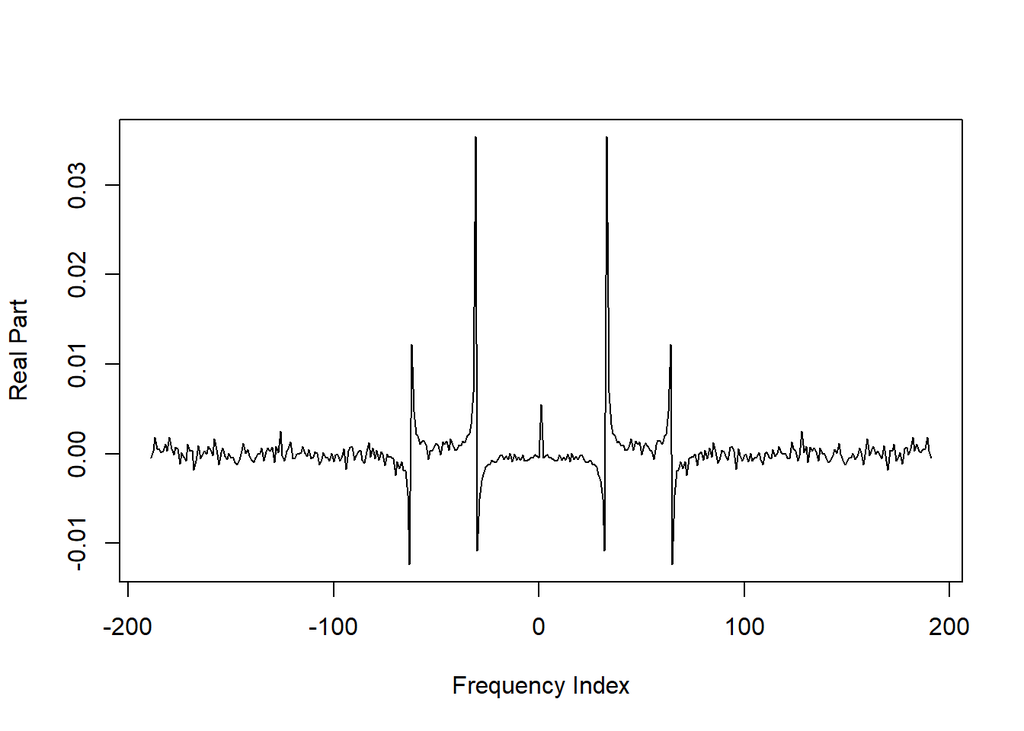

```r
mau <- read.table("mauna.dat",header=TRUE,sep="")
mau <- ts(mau,start=1958,frequency=12)
mau.gr <- diff(log(mau))
n <- length(mau.gr)
Q.mat <- get.qmat(n)
x.dft <- Conj(t(Q.mat)) %*% mau.gr
plot(ts(Re(x.dft),start=-floor(n/2)+1,frequency=1),
    xlab="Frequency Index",ylab="Real Part")
```

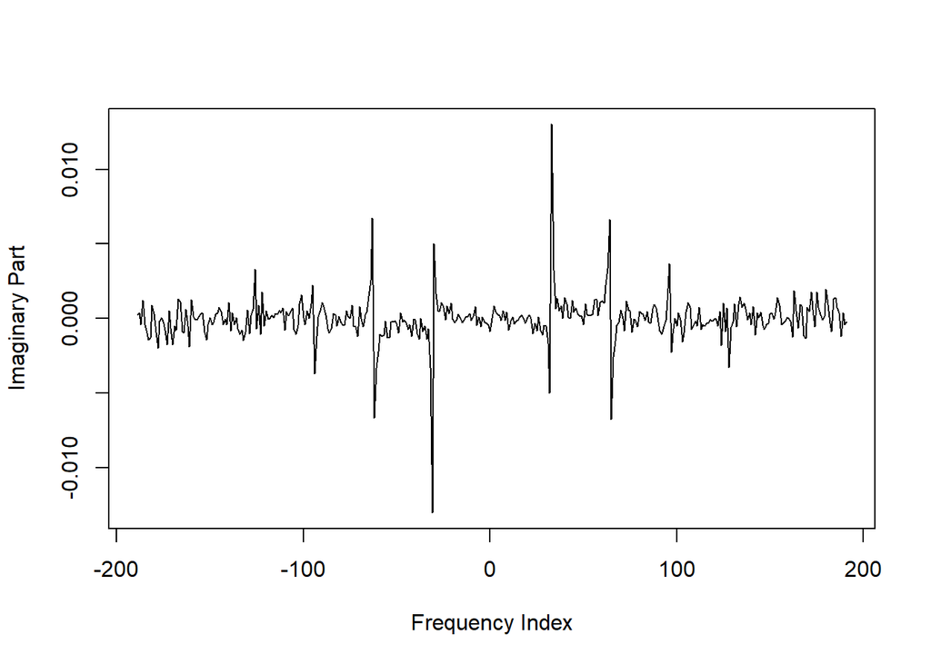

```r
plot(ts(Im(x.dft),start=-floor(n/2)+1,frequency=1),
    xlab="Frequency Index",ylab="Imaginary Part")
```

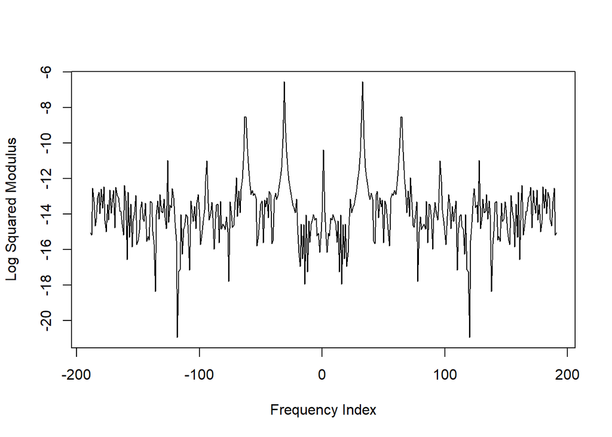

```r
plot(ts(log(Mod(x.dft)^2),start=-floor(n/2)+1,frequency=1),
    xlab="Frequency Index",ylab="Log Squared Modulus")
```

- We see higher values of the uncentered periodogram in the shape of peaks, at four non-zero frequencies. These correspond to cyclical seasonal effects.